# Daudzdimensiju mērogošana

Uz sākumu

## Ievads

Daudzdimensiju mērogošana ir paņēmienu kopums, kas pārveido galīgu kopu ar uzdotu savstarpējo *attālumu matricu* (*distance matrix*) par punktiem $n$-dimensiju Dekarta telpā.

Piedāvājam piemēru, kur 17 dažādas figūriņas dažādi lietotāji ir novērtējuši septiņās atšķirīgās emociju skalās (katra skala ir starp divām pretējām emocijām un katrs no aptaujātajiem dažām no figūriņām izvēlējās uz šīm skalām vērtības no $0$ līdz $100$).

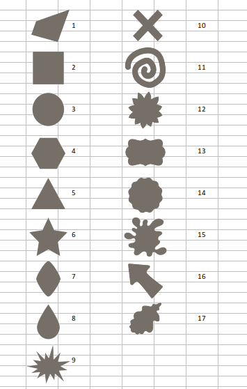

Attēls: 17 figūriņas

Šādi izskatījās 7 *slīdņi* (*sliders*) ar emociju diapazoniem:

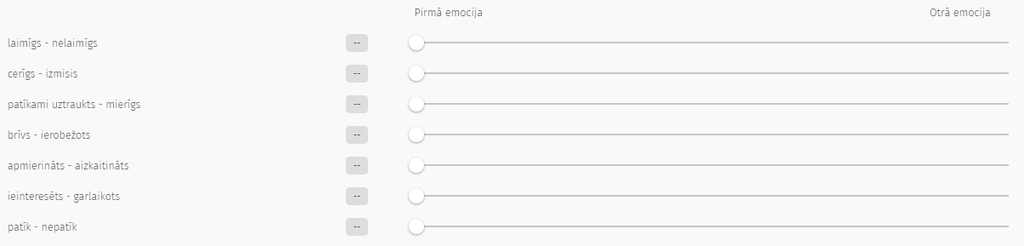

Attēls: Emociju intervāli

Bija 2 datu faili `RawData-emotions-shapes.csv` (Aptauja 1) un `RawData-shapes-emotions.csv` (Aptauja 2).

## Vai visas emociju skalas ir vienlīdz “precīzas”?

Atkarībā no figūriņas un pretējo emociju pāra bija visai atšķirīgas atbilžu izkliedes (standartnovirzes, ko iegūst, salīdzinot visas atbildes, kurās dažādi respondenti piekārtoja tai pašai figūriņai to pašu emociju slīdņa vērtību).

### Pirmā datu kopa

Datu kopā `RawData-emotions-shapes.csv` ir 28 respondentu atbildes, kam aptauju sistēmā izveidoti unikāli identifikatori par 222 figūriņām. Šeit dota standartnoviržu matrica tām skaitļu virknītēm, kā attiecīgo figūriņu (ar numuru no $1$ līdz $17$, izņemot numuru $12$) novērtēja attiecībā pret kādu no $7$ emociju skalām.

|  | 1 | 2 | 3 | 4 | 5 | 6 | 7 | 8 | 9 | 10 | 11 | 13 | 14 | 15 | 16 | 17 |
| --- | --- | --- | --- | --- | --- | --- | --- | --- | --- | --- | --- | --- | --- | --- | --- | --- |
| rLaimNelaim | 35.82 | 35.80 | 26.73 | 31.62 | 25.29 | 25.72 | 30.49 | 34.10 | 33.49 | 28.80 | 36.90 | 29.44 | 21.64 | 34.30 | 29.68 | 30.90 |
| rCerIzmis | 30.85 | 27.57 | 32.33 | 35.38 | 23.04 | 26.93 | 34.76 | 34.67 | 27.88 | 28.07 | 36.04 | 31.82 | 22.28 | 29.35 | 29.98 | 34.50 |
| rUztrMier | 27.01 | 31.30 | 17.04 | 32.20 | 37.12 | 31.13 | 20.10 | 30.04 | 35.71 | 27.19 | 38.17 | 30.08 | 33.86 | 27.11 | 26.82 | 25.07 |
| rBrivIerob | 33.27 | 34.32 | 38.84 | 33.01 | 35.22 | 27.56 | 37.79 | 36.43 | 23.39 | 27.14 | 38.47 | 29.30 | 31.51 | 32.91 | 29.76 | 37.99 |
| rApmAizkait | 34.24 | 30.39 | 21.08 | 33.25 | 21.48 | 27.15 | 31.80 | 35.78 | 27.58 | 31.87 | 31.48 | 31.13 | 27.37 | 29.14 | 29.91 | 36.20 |
| rInterGarl | 31.55 | 31.84 | 34.25 | 23.34 | 34.50 | 29.60 | 33.78 | 33.74 | 30.85 | 31.56 | 40.31 | 32.36 | 26.03 | 28.05 | 31.08 | 24.71 |
| rPatNepat | 33.29 | 34.44 | 32.59 | 27.51 | 30.87 | 24.98 | 32.94 | 33.74 | 31.64 | 28.82 | 35.68 | 30.52 | 29.06 | 31.90 | 31.69 | 34.34 |

Zemāk attēlots heatmap-s ar atbilstošajām standartnoviržu vērtībām. Zilās rūtiņas atbilst zemai standartnovirzei (konsekventām atbildēm no vairākiem respondentiem), sarkanās - augstai standartnovirzei (augstai atbilžu izkliedei).

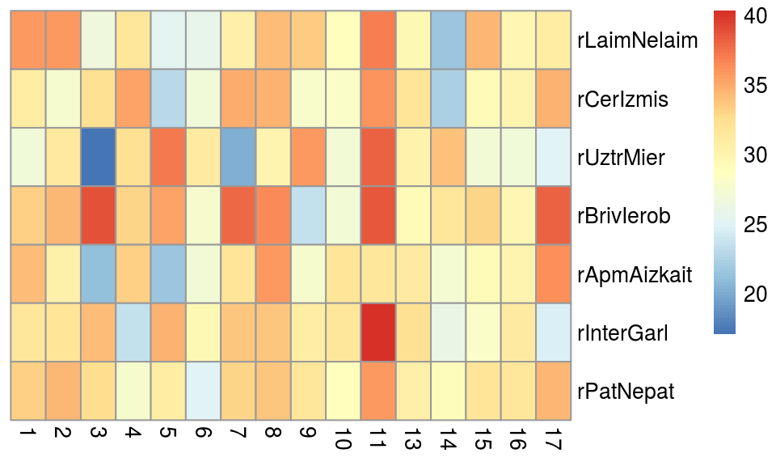

*Attēls: Standartnovirze figūriņas-emocijas pārim no* `RawData-emotions-shapes.csv`

### Otrā datu kopa

Failā `RawData-shapes-emotions.csv` atrodamas 29 respondentu atbildes - visi kopā viņi izvērtējuši $206$ figūriņas, pierakstot katrai no tām visas septiņas emociju skalas.  
Šajā datu kopā trūkst nav figūriņas #12 (margrietiņa), nav atbilžu arī par figūriņām #2 (kvadrāts), #3 (aplis), #4 (sešstūris), #5 (trijstūris).

|  | 1 | 6 | 7 | 8 | 9 | 10 | 11 | 13 | 14 | 15 | 16 | 17 |
| --- | --- | --- | --- | --- | --- | --- | --- | --- | --- | --- | --- | --- |
| rLaimNelaim | 35.63 | 27.64 | 30.57 | 34.45 | 32.57 | 30.95 | 32.03 | 30.05 | 24.90 | 29.21 | 28.30 | 30.21 |
| rCerIzmis | 29.88 | 29.43 | 37.08 | 34.85 | 31.36 | 32.45 | 25.50 | 28.85 | 22.60 | 24.82 | 30.48 | 36.87 |
| rUztrMier | 25.91 | 32.07 | 23.83 | 30.14 | 34.88 | 27.95 | 37.87 | 32.88 | 32.98 | 27.02 | 24.05 | 18.72 |
| rBrivIerob | 34.06 | 28.80 | 34.11 | 32.58 | 26.37 | 24.48 | 39.85 | 28.56 | 33.81 | 31.48 | 27.57 | 37.42 |
| rApmAizkait | 31.94 | 31.09 | 33.81 | 39.35 | 30.24 | 33.70 | 28.83 | 33.54 | 28.50 | 23.56 | 30.59 | 36.75 |
| rInterGarl | 32.01 | 32.68 | 29.13 | 35.63 | 31.24 | 29.20 | 40.59 | 37.13 | 28.90 | 33.25 | 31.07 | 14.96 |
| rPatNepat | 30.90 | 25.91 | 32.62 | 36.76 | 33.72 | 29.63 | 27.62 | 32.51 | 31.21 | 31.61 | 31.40 | 29.06 |

Seko heatmap-s ar šiem pašiem skaitļiem:

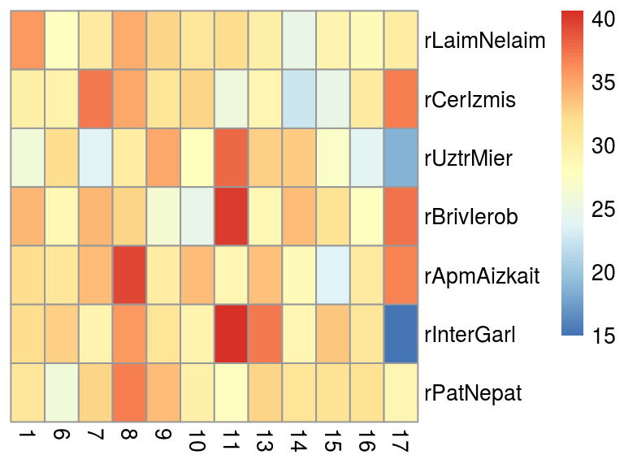

*Attēls: Standartnovirze figūriņas-emocijas pārim no* `RawData-shapes-emotions.csv`

No otras puses, nav novērots, ka viena no emociju skalām būtu krietni precīzāka (visām figūriņām) par kādu citu skalu. Standartnovirzes katrai no septiņām skalām (ja skaita rezultātus pa visām figūriņām kopā) bija robežās $[29;33]$. Tādēļ turpmāk uzskatīsim visu emociju skalu datus par vienlīdz ticamiem un precīziem. (Ja dažas skalas būtu krietni neprecīzākas par citām, tad rastos jautājums par ievadīto skaitlisko atbilžu $a \in [0;100]$ ticamību vai par pašu uzstādīto jautājumu piemērotību respondentu spējai uz tiem atbildēt.)

## Vai visas emociju skalas ir savstarpēji “neatkarīgas”?

Ja aplūkojam vidējās vērtības tam kā figūriņu $S_i$ ($i=1,\ldots,17$) novērtēja attiecībā pret emociju $E_j$ ($j=1,\ldots,7$), un apzīmējam vidējās atbildes ar $a(i,j)$, tad var novērtēt Pīrsona korelācijas koeficientus, salīdzinot $a(i,j_1)$ un $a(i,j_2)$ jebkurām divām emociju skalām $E_{j_1}$ un $E_{j_2}$, kur $i$ mainās pa visām figūriņām. Augsts korelācijas koeficients nozīmē to, ka emociju skalas ir līdzīgas (mēra apmēram to pašu par katru doto figūriņu).

|  | E_1 | E_2 | E_3 | E_4 | E_5 | E_6 | E_7 |
| --- | --- | --- | --- | --- | --- | --- | --- |
| E_1 | 1.0000 | 0.9027 | -0.0674 | 0.5659 | 0.8187 | 0.4425 | 0.8995 |
| E_2 | 0.9027 | 1.0000 | -0.3827 | 0.4031 | 0.9526 | 0.2219 | 0.8746 |
| E_3 | -0.0674 | -0.3827 | 1.0000 | 0.2495 | -0.5549 | 0.6293 | -0.2756 |
| E_4 | 0.5659 | 0.4031 | 0.2495 | 1.0000 | 0.3280 | 0.7015 | 0.5786 |
| E_5 | 0.8187 | 0.9526 | -0.5549 | 0.3280 | 1.0000 | 0.0737 | 0.8601 |
| E_6 | 0.4425 | 0.2219 | 0.6293 | 0.7015 | 0.0737 | 1.0000 | 0.3936 |
| E_7 | 0.8995 | 0.8746 | -0.2756 | 0.5786 | 0.8601 | 0.3936 | 1.0000 |

No matricas redzam, ka, teiksim, emociju skalām $E_2$ (cerīgs-izmisis) un $E_5$ (apmierināts-aizkaitināts) ir augsts korelācijas koeficients $r = 0.95$. Tas nozīmē, ka emociju skaitļa $E_2$ izmaiņa (pārejot no vienas figūriņas uz citu) izskaidro $r^2$ jeb aptuveni 90% no emociju skaitļa $E_5$ izmaiņas un otrādi.

Precīzākai salīdzināšanai būtu jāskatās nevis agregētie dati (vidējie emociju skaitļi pa visiem respondentiem), bet gan instanču dati (vai arī atsevišķie respondenti vērtēja skalas $E_2$ un $E_5$ ļoti līdzīgi)? Tas šeit nav izdarīts.

## Pirmās datu kopas emociju vērtējumi

Aplūkosim katru no $16$ figūriņām kā “punktu” 7-dimensiju telpā. (tās ir figūras no $1$ līdz $17$, izņemot #12, par kuru mums nav datu). Katra no dimensijām ir skaitlis robežās $[0;100]$ - vidējais vērtējums attiecīgajā emociju skalā. Piemēram, 1.figūriņai (taisnleņķa trapece) atbilst šādas koordinātes:
$$S_1 = (51.46, 46.03, 40.34, 60.51, 51.91, 42.26, 60.09).$$

|  | 1 | 2 | 3 | 4 | 5 | 6 | 7 | 8 | 9 | 10 | 11 | 13 | 14 | 15 | 16 | 17 |
| --- | --- | --- | --- | --- | --- | --- | --- | --- | --- | --- | --- | --- | --- | --- | --- | --- |
| rLaimNelaim | 51.46 | 58.71 | 47.3 | 24.79 | 28.15 | 27.80 | 51.48 | 39.52 | 37.03 | 51.23 | 37.32 | 45.82 | 15.17 | 39.50 | 51.48 | 50.58 |
| rCerIzmis | 46.03 | 63.07 | 57.4 | 28.64 | 18.55 | 26.43 | 48.14 | 43.97 | 28.03 | 43.61 | 28.43 | 41.85 | 14.50 | 31.43 | 48.79 | 57.90 |
| rUztrMier | 40.34 | 38.43 | 15.5 | 40.64 | 51.20 | 61.70 | 25.57 | 31.91 | 55.06 | 68.74 | 70.71 | 52.97 | 28.64 | 63.80 | 63.14 | 26.45 |
| rBrivIerob | 60.51 | 71.21 | 36.1 | 34.57 | 48.00 | 35.97 | 42.76 | 38.64 | 22.50 | 76.16 | 54.32 | 64.62 | 32.50 | 42.53 | 38.66 | 45.94 |
| rApmAizkait | 51.91 | 64.57 | 68.8 | 24.57 | 21.70 | 27.57 | 51.52 | 46.36 | 32.44 | 43.29 | 28.54 | 39.74 | 20.17 | 27.57 | 39.83 | 63.55 |
| rInterGarl | 42.26 | 61.86 | 33.7 | 26.21 | 42.00 | 51.80 | 32.95 | 32.36 | 29.00 | 60.61 | 49.18 | 49.56 | 18.92 | 41.67 | 50.69 | 19.39 |
| rPatNepat | 60.09 | 69.21 | 48.4 | 23.64 | 33.45 | 36.07 | 52.19 | 43.91 | 35.94 | 48.26 | 29.04 | 46.88 | 23.69 | 36.57 | 44.83 | 52.10 |

Tās emociju “dimensijas”, kuras ir pārāk stipri korelētas ar citām, iespējams, vajadzētu aplūkot ar samazinātu svaru (piemēram, “apmierināts-aizkaitināts” un “cerīgs-izmisis”). Tomēr, vienkāršības dēļ uzskatīsim visas tās par vienlīdzīgām un definēsim starp figūriņām parasto Eiklīda attālumu $7$-dimensiju telpā. Piemēram, attālums starp #1 (trapeci) un #2 (kvadrātu) izsakāms šādi:
$$d(S_1,S_2) = \sqrt{(51.46-58.71)^2 + \ldots + (60.09 - 69.21)^2} = 33.$$

Attēlosim savstarpējos figūriņu attālumus $16 \times 16$ matricā:

|  | S_1 | S_2 | S_3 | S_4 | S_5 | S_6 | S_7 | S_8 | S_9 | S_10 | S_11 | S_13 | S_14 | S_15 | S_16 | S_17 |
| --- | --- | --- | --- | --- | --- | --- | --- | --- | --- | --- | --- | --- | --- | --- | --- | --- |
| S_1 | 0.00 | 33.00 | 43.07 | 63.40 | 56.53 | 57.12 | 26.21 | 32.97 | 57.72 | 40.11 | 55.04 | 24.52 | 78.17 | 48.74 | 38.15 | 35.63 |
| S_2 | 33.00 | 0.00 | 56.26 | 92.90 | 84.44 | 81.56 | 50.45 | 60.66 | 86.99 | 47.66 | 77.84 | 46.24 | 108.34 | 75.36 | 57.08 | 54.53 |
| S_3 | 43.07 | 56.26 | 0.00 | 67.78 | 76.18 | 75.19 | 23.71 | 32.28 | 64.94 | 77.59 | 80.97 | 59.66 | 79.07 | 70.80 | 59.23 | 21.77 |
| S_4 | 63.40 | 92.90 | 67.78 | 0.00 | 27.54 | 35.74 | 54.53 | 38.32 | 26.92 | 74.71 | 44.99 | 54.65 | 22.66 | 35.20 | 54.06 | 65.02 |
| S_5 | 56.53 | 84.44 | 76.18 | 27.54 | 0.00 | 21.32 | 58.54 | 45.23 | 33.53 | 57.39 | 26.84 | 41.20 | 39.55 | 22.97 | 47.14 | 72.66 |
| S_6 | 57.12 | 81.56 | 75.19 | 35.74 | 21.32 | 0.00 | 59.77 | 46.17 | 29.27 | 54.61 | 23.88 | 41.59 | 51.92 | 17.67 | 36.03 | 73.85 |
| S_7 | 26.21 | 50.45 | 23.71 | 54.53 | 58.54 | 59.77 | 0.00 | 17.70 | 50.37 | 62.03 | 63.94 | 41.75 | 67.51 | 52.71 | 43.98 | 20.87 |
| S_8 | 32.97 | 60.66 | 32.28 | 38.32 | 45.23 | 46.17 | 17.70 | 0.00 | 36.41 | 61.06 | 53.10 | 38.88 | 52.78 | 41.03 | 39.00 | 30.50 |
| S_9 | 57.72 | 86.99 | 64.94 | 26.92 | 33.53 | 29.27 | 50.37 | 36.41 | 0.00 | 69.14 | 41.57 | 51.40 | 43.15 | 26.08 | 39.63 | 61.36 |
| S_10 | 40.11 | 47.66 | 77.59 | 74.71 | 57.39 | 54.61 | 62.03 | 61.06 | 69.14 | 0.00 | 40.28 | 23.47 | 92.41 | 46.73 | 39.84 | 70.93 |
| S_11 | 55.04 | 77.84 | 80.97 | 44.99 | 26.84 | 23.88 | 63.94 | 53.10 | 41.57 | 40.28 | 0.00 | 33.43 | 62.81 | 17.74 | 36.02 | 75.63 |
| S_13 | 24.52 | 46.24 | 59.66 | 54.65 | 41.20 | 41.59 | 41.75 | 38.88 | 51.40 | 23.47 | 33.43 | 0.00 | 71.91 | 32.72 | 29.38 | 53.26 |
| S_14 | 78.17 | 108.34 | 79.07 | 22.66 | 39.55 | 51.92 | 67.51 | 52.78 | 43.15 | 92.41 | 62.81 | 71.91 | 0.00 | 54.35 | 74.60 | 77.54 |
| S_15 | 48.74 | 75.36 | 70.80 | 35.20 | 22.97 | 17.67 | 52.71 | 41.03 | 26.08 | 46.73 | 17.74 | 32.72 | 54.35 | 0.00 | 27.58 | 65.29 |
| S_16 | 38.15 | 57.08 | 59.23 | 54.06 | 47.14 | 36.03 | 43.98 | 39.00 | 39.63 | 39.84 | 36.02 | 29.38 | 74.60 | 27.58 | 0.00 | 55.48 |
| S_17 | 35.63 | 54.53 | 21.77 | 65.02 | 72.66 | 73.85 | 20.87 | 30.50 | 61.36 | 70.93 | 75.63 | 53.26 | 77.54 | 65.29 | 55.48 | 0.00 |

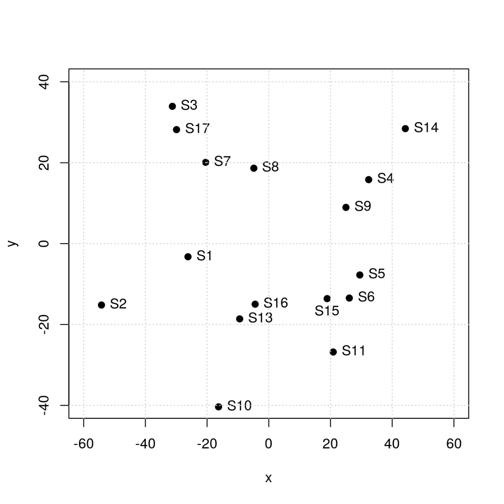

*Attēls: MDS 16 figūriņām (pirmā datu kopa)*

Interpretēt šo zīmējumu ir grūti, kamēr mēs nezinām, kādu nozīmi aptaujātie piedēvēja dažādajām emociju skalām. Mēs, piemēram, varam pateikt, ka attālums $d(S_3, S_{11}) = 80.97$ (attālums starp apli un spirāli) ir viens no lielākajiem visā attālumu tabulā, tādēļ arī “iebāžot” 7-dimensiju telpu 2-dimensiju telpā, atbilstošie punkti $S_3$ un $S_{11}$ būs pietiekami tālu viens no otra - tie ir divi galējie punkti uz “ziemeļrietumu-dienvidaustrumu” ass.

Bet citu punktu interpretācija jau vairs nav tik skaidra. Piemēram $S_{17}$ (ozollapa) pēc 7-dimensiju Eiklīda attāluma ir ļoti tuvu $S_3$ (aplim); savukārt $S_{15}$ (kleksis) ir ļoti tuvu $S_{11}$ (spirālei).

## Pārbaude ar Otro Datu kopu

Attēlosim savstarpējos figūriņu attālumus $12 \times 12$ matricā:

|  | S_1 | S_6 | S_7 | S_8 | S_9 | S_10 | S_11 | S_13 | S_14 | S_15 | S_16 | S_17 |
| --- | --- | --- | --- | --- | --- | --- | --- | --- | --- | --- | --- | --- |
| S_1 | 0.00 | 59.16 | 33.29 | 41.55 | 47.89 | 41.71 | 65.54 | 40.48 | 75.62 | 76.40 | 40.49 | 45.73 |
| S_6 | 59.16 | 0.00 | 52.04 | 52.66 | 34.66 | 62.31 | 34.54 | 33.65 | 51.56 | 24.88 | 32.46 | 71.39 |
| S_7 | 33.29 | 52.04 | 0.00 | 30.79 | 40.99 | 57.77 | 54.45 | 33.79 | 47.46 | 61.13 | 45.88 | 30.57 |
| S_8 | 41.55 | 52.66 | 30.79 | 0.00 | 35.01 | 73.07 | 70.06 | 50.68 | 58.22 | 68.03 | 43.11 | 24.89 |
| S_9 | 47.89 | 34.66 | 40.99 | 35.01 | 0.00 | 64.03 | 52.34 | 43.51 | 58.52 | 50.09 | 30.30 | 48.56 |
| S_10 | 41.71 | 62.31 | 57.77 | 73.07 | 64.03 | 0.00 | 53.03 | 40.14 | 89.97 | 74.29 | 44.41 | 79.76 |
| S_11 | 65.54 | 34.54 | 54.45 | 70.06 | 52.34 | 53.03 | 0.00 | 27.75 | 54.02 | 30.43 | 47.38 | 81.09 |
| S_13 | 40.48 | 33.65 | 33.79 | 50.68 | 43.51 | 40.14 | 27.75 | 0.00 | 51.51 | 43.68 | 34.20 | 61.81 |
| S_14 | 75.62 | 51.56 | 47.46 | 58.22 | 58.52 | 89.97 | 54.02 | 51.51 | 0.00 | 44.84 | 70.51 | 64.58 |
| S_15 | 76.40 | 24.88 | 61.13 | 68.03 | 50.09 | 74.29 | 30.43 | 43.68 | 44.84 | 0.00 | 52.41 | 82.65 |
| S_16 | 40.49 | 32.46 | 45.88 | 43.11 | 30.30 | 44.41 | 47.38 | 34.20 | 70.51 | 52.41 | 0.00 | 60.46 |
| S_17 | 45.73 | 71.39 | 30.57 | 24.89 | 48.56 | 79.76 | 81.09 | 61.81 | 64.58 | 82.65 | 60.46 | 0.00 |

Šo attālumu matricu cenšoties (ar minimālām deformācijām) ievietot 2D telpā, iegūstam šādu daudzdimensiju mērogošanas attēlu:

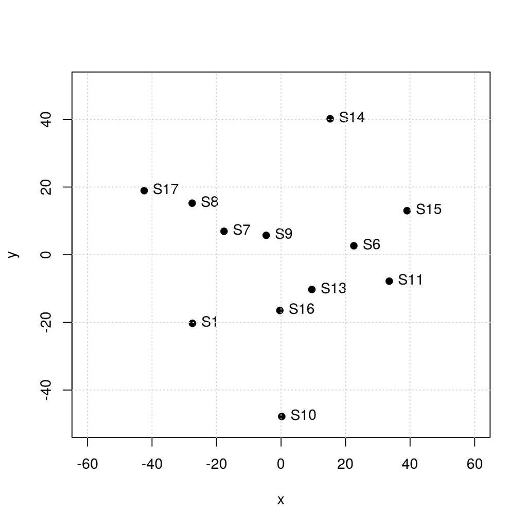

Kā redzams, datiem piemīt dažas likumsakarības, kas sakrīt pirmajā un otrajā datu kopā. Arī šajā attēlā divus galējos stāvokļus ieņem figūriņas $S_{14}$ (aplītis ar viļņainu maliņu) un $S_{10}$ (slīps krustiņš). Savukārt uz otras diagonāles pretējos stūros ir attēli $S_{17}$ (ozollapa) un $S_{11}/S_{15}$ (spirāle un kleksis).

## Citi avoti

- [D3 Diagrammas figūriņām/emocijām](http://bustling-dynamo-253414.appspot.com/).
- [Par daudzdimensiju mērogošanu (MDS)](https://en.wikipedia.org/wiki/Multidimensional_scaling)
- [Kā daudzdimensiju mērogošanu zīmēt ar R](https://www.r-bloggers.com/multidimensional-scaling-mds-with-r/)
- [Knitr ar Markdown: Lapā izmantotā tehnoloģija](https://yihui.org/knitr/demo/minimal/)